# Dispersión y distribución de los retornos — repaso con teoría

Este notebook retoma el portafolio de 5 ETFs de la unidad **Retornos y portafolios manuales** (mismos tickers, mismos pesos) y le aplica las medidas que describen la forma de la distribución de sus retornos: dispersión (desviación estándar), forma (asimetría y curtosis), y las dos medidas de riesgo de cola que ya vimos en la unidad de VaR/ES, esta vez comparando cada activo individual contra el portafolio combinado.

## Configuración inicial

```r
if (!require("pacman")) install.packages("pacman")
```

```r
pacman::p_load(tidyverse, EnvStats, ggpubr, psych, quantmod, TTR,
               purrr, PerformanceAnalytics, highcharter, timetk, readxl, scales)
options(scipen = 999)
```

# Parte 0 — Reconstrucción del portafolio

**Qué hace**: repite, de forma condensada, la descarga y construcción del portafolio de la unidad anterior (5 ETFs, retornos mensuales continuos, pesos 25/25/20/20/10 con rebalanceo mensual) — necesario para tener `retornos_mes` y `portfolio_retornos_mes` disponibles en este notebook.

```r
symbols <- c("SPY","EFA", "IJS", "EEM", "AGG")

precios <- quantmod::getSymbols(symbols,
                                src = 'yahoo',
                                from = "2010-12-31",
                                periodicity = "daily",
                                auto.assign = TRUE,
                                warnings = FALSE) %>%
    purrr::map(~quantmod::Ad(get(.))) %>%
    purrr::reduce(merge.xts) %>%
    `colnames<-`(symbols)

precios_mes <- xts::to.monthly(x = precios, indexAt = "lastof", OHLC = FALSE)
retornos_mes <- diff(log(precios_mes)) %>% na.omit()

retornos_mes_long <- retornos_mes %>%
    tk_tbl(rename_index = "date") %>%
    gather(key = activo, value = retorno, -date, factor_key = T)

w <- c(0.25, 0.25, 0.20, 0.20, 0.10)

portfolio_retornos_mes <- PerformanceAnalytics::Return.portfolio(R = retornos_mes,
                                                                 weights = w,
                                                                 rebalance_on = "months") %>%
  `colnames<-`("retornos")

tail(portfolio_retornos_mes)
```

```
##                retornos
## 2026-04-30  0.079542345
## 2026-05-31  0.035169507
## 2026-06-30  0.009632109
## 2026-07-31 -0.011262282
## 2026-08-31  0.021298645
## 2026-09-30 -0.003042462
```

# Parte 1 — Desviación estándar

**Qué hace**: calcula la desviación estándar mensual de cada activo y del portafolio combinado, y grafica cada retorno del portafolio en el tiempo coloreado según si cae dentro o fuera de una banda de ±1 desviación estándar alrededor de la media.

**Por qué (teoría)**: la desviación estándar es la medida de dispersión más usada para volatilidad porque resume, en un solo número, qué tan lejos tienden a estar los retornos de su promedio. Pero es una medida *simétrica* — penaliza igual una sorpresa positiva que una negativa —, algo que conviene tener presente antes de usarla como la única medida de riesgo (de ahí que más adelante se complemente con asimetría, curtosis, VaR y ES).

```r
PerformanceAnalytics::StdDev(R = retornos_mes)*100
```

```
##             SPY      EFA      IJS      EEM      AGG
## StdDev 4.042297 4.283148 5.775851 5.173803 1.286093
```

```r
PerformanceAnalytics::StdDev(R = retornos_mes, weights = w)*100
```

```
##         [,1]
## [1,] 3.90013
```

## Dispersión de los retornos del portafolio en el tiempo

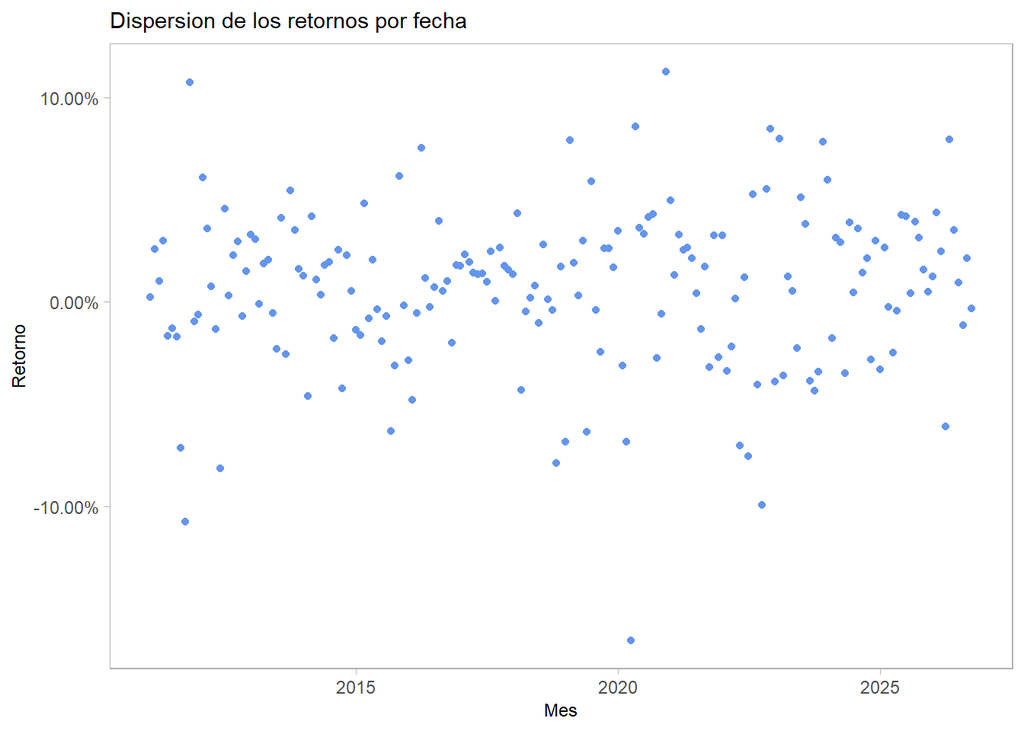

```r
portfolio_retornos_mes %>%
    ggplot(mapping = aes(x = index(.), y = retornos)) +
    geom_point(color = "cornflowerblue") +
    labs(title = "Dispersion de los retornos por fecha", x = "Mes", y = "Retorno") +
    theme_light() +
    theme(plot.title = element_text(size = 11),
          axis.title = element_text(size = 9),
          panel.grid = element_blank()) +
    scale_y_continuous(labels = label_percent(accuracy = 0.01))
```

## Retornos dentro y fuera de ±1 desviación estándar

**Qué hace**: azul = dentro de la banda (media ± 1 sd), verde = por encima (sorpresa positiva grande), rojo = por debajo (sorpresa negativa grande). Con una distribución normal se esperaría que ~68% de los puntos caigan en azul — es una forma visual rápida de chequear si los retornos reales se comportan como normales o tienen colas más gordas de lo esperado.

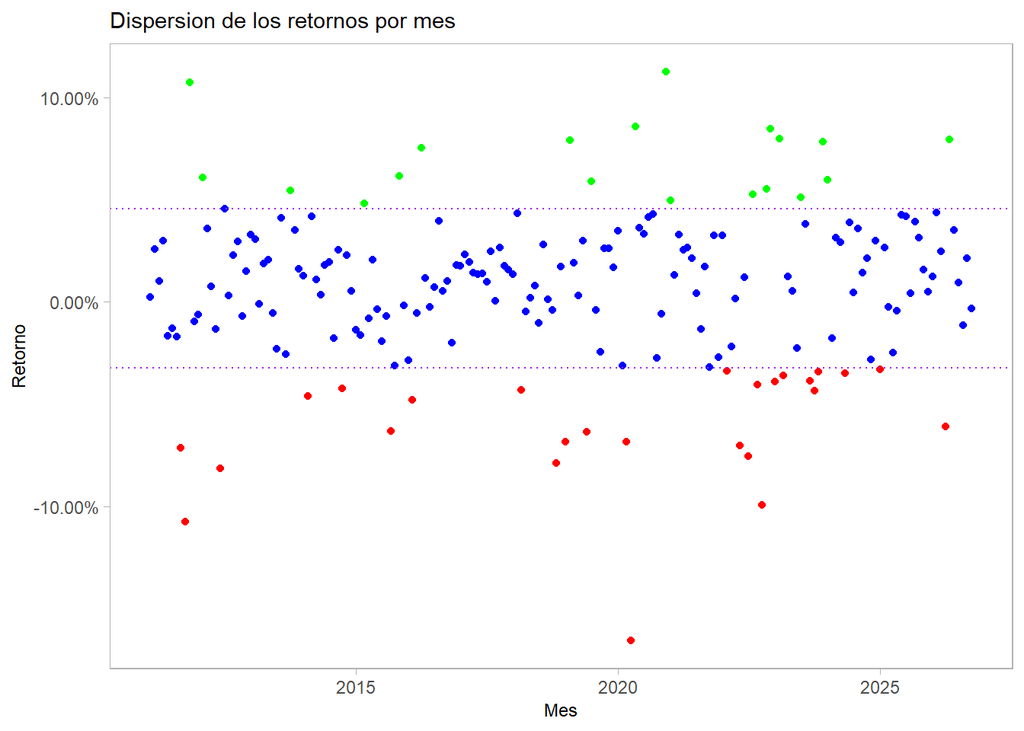

```r
sd_plot <- sd(portfolio_retornos_mes)
mean_plot <- mean(portfolio_retornos_mes)

portfolio_retornos_mes %>%
  as.data.frame() %>%
  rownames_to_column(var = "Fecha") %>%
  mutate(Fecha = ymd(Fecha)) %>%
  mutate(hist_col_red = if_else(retornos < (mean_plot - sd_plot),
                                retornos, as.numeric(NA)),
         hist_col_green = if_else(retornos > (mean_plot + sd_plot),
                                  retornos, as.numeric(NA)),
         hist_col_blue = if_else(retornos >= (mean_plot - sd_plot) & retornos <= (mean_plot + sd_plot),
                                 retornos, as.numeric(NA))) %>%
  ggplot(aes(x = Fecha)) +
  geom_point(aes(y = hist_col_red),
             color = "red") +
  geom_point(aes(y = hist_col_green),
             color = "green") +
  geom_point(aes(y = hist_col_blue),
             color = "blue") +
  geom_hline(yintercept = (mean_plot + sd_plot),
             color = "purple",
             linetype = "dotted") +
  geom_hline(yintercept = (mean_plot-sd_plot),
             color = "purple",
             linetype = "dotted") +
  labs(title = "Dispersion de los retornos por mes", y = "Retorno", x = "Mes") +
  scale_x_date(breaks = pretty_breaks(n = 6)) +
  scale_y_continuous(labels = label_percent(accuracy = 0.01)) +
  theme_light() +
  theme(plot.title = element_text(size = 11),
        axis.title = element_text(size = 9),
        panel.grid = element_blank())
```

## Retorno esperado vs riesgo (StdDev)

**Por qué (teoría)**: este es el mismo tipo de gráfico riesgo-retorno que se usa como base de la frontera eficiente de Markowitz — cada punto es un activo (o el portafolio) ubicado según cuánto retorno promedio da y cuánta desviación estándar asume para darlo. Un buen portafolio diversificado debería quedar más a la izquierda (menos riesgo) que sus componentes más volátiles, sin sacrificar todo el retorno.

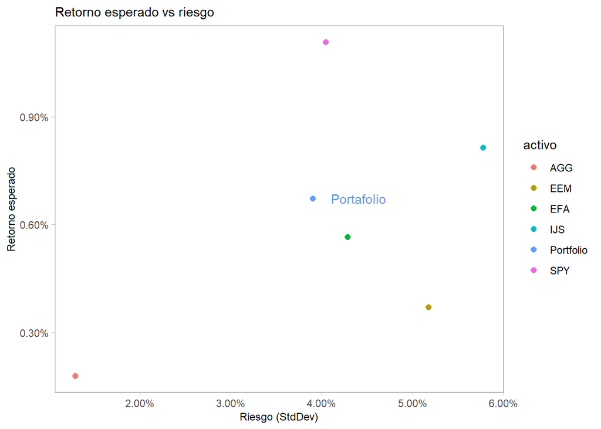

```r
retornos_mes_long %>%
  group_by(activo) %>%
  summarise(retorno_esperado = mean(retorno),
            desviacion = sd(retorno)) %>%
  add_row(activo = "Portfolio",
          desviacion =
            sd(portfolio_retornos_mes),
          retorno_esperado =
            mean(portfolio_retornos_mes)) %>%
  ggplot(aes(x = desviacion,
             y = retorno_esperado,
             color = activo)) +
  geom_point(size = 2) +
  annotate("text",
           x = sd(portfolio_retornos_mes) * 1.13,
           y = mean(portfolio_retornos_mes),
           label = "Portafolio", color = "cornflowerblue") +
  theme_light() +
  labs(title = "Retorno esperado vs riesgo",
       x = "Riesgo (StdDev)",
       y = "Retorno esperado") +
  theme(plot.title = element_text(size = 11),
        axis.title = element_text(size = 9),
        panel.grid = element_blank()) +
  scale_y_continuous(labels = label_percent(accuracy = 0.01)) +
  scale_x_continuous(labels = label_percent(accuracy = 0.01))
```

## Desviación estándar con ventana móvil

**Por qué (teoría)**: la volatilidad no es constante en el tiempo (se llama *clustering* de volatilidad — periodos tranquilos tienden a seguir a periodos tranquilos, y periodos turbulentos a periodos turbulentos). Una ventana móvil de 24 meses muestra cómo cambió el riesgo real del portafolio a través de crisis y periodos de calma, en vez de un solo número fijo para toda la historia.

```r
ventana <- 24 # Dos años

rolling_sd <- rollapply(data = portfolio_retornos_mes,
                        width = ventana,
                        FUN = sd) %>%
  na.omit() %>%
  `colnames<-`("rolling_sd")

highchart(type = "stock") %>%
  hc_title(text = "Volatilidad movil de 24 meses") %>%
  hc_add_series(round(rolling_sd,4)*100,
                color = "cornflowerblue",
                name = "StdDev") %>%
  hc_add_theme(hc_theme_gridlight()) %>%
  hc_yAxis(labels = list(format = "{value}%"),
           opposite = FALSE,
           title = list(text = "StdDev")) %>%
  hc_navigator(height = 20) %>%
  hc_scrollbar(enabled = F) %>%
  hc_exporting(enabled= T)
```

[interactive chart not shown]

# Parte 2 — Asimetría (skewness)

**Qué hace**: calcula qué tan simétrica es la distribución de retornos alrededor de su media, por activo, por portafolio, y en una ventana móvil de 24 meses.

**Por qué (teoría)**: la asimetría mide si las sorpresas grandes tienden a ser más frecuentes hacia arriba o hacia abajo. Una asimetría negativa (la más común en retornos de renta variable) significa que las caídas grandes son más extremas o más frecuentes que las subidas grandes — los mercados suben escalando y bajan de golpe. Es información que la desviación estándar, al ser simétrica, no captura en absoluto.

```r
PerformanceAnalytics::skewness(retornos_mes)
```

|  | SPY | EFA | IJS | EEM | AGG |
| --- | --- | --- | --- | --- | --- |
| Skewness | -0.4974669 | -0.5086841 | -0.6659927 | -0.3496213 | -0.189828 |

```r
PerformanceAnalytics::skewness(portfolio_retornos_mes)
```

```
## [1] -0.6497813
```

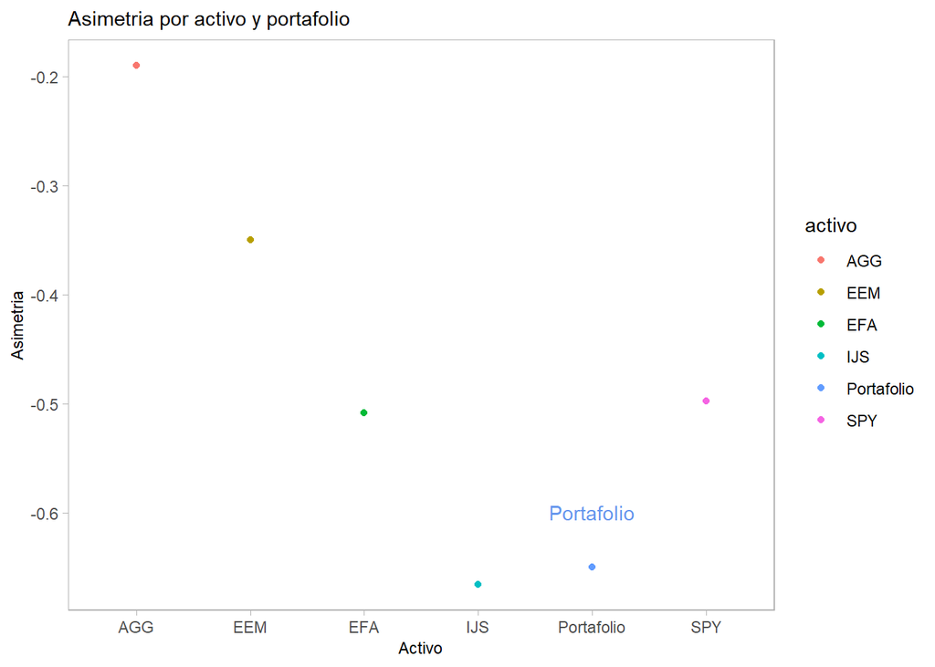

```r
retornos_mes_long %>%
  group_by(activo) %>%
  summarize(skew_accion = skewness(retorno)) %>%
  add_row(activo = "Portafolio",
          skew_accion = skewness(portfolio_retornos_mes)) %>%
  ggplot(aes(x = activo,
             y = skew_accion,
             colour = activo)) +
  geom_point() +
  annotate("text",
           x = "Portafolio",
           y = skewness(portfolio_retornos_mes) + 0.05,
           label = "Portafolio",
           color = "cornflowerblue") +
  theme_light() +
  labs(title = "Asimetria por activo y portafolio", x = "Activo", y = "Asimetria") +
  theme(plot.title = element_text(size = 11),
        axis.title = element_text(size = 9),
        panel.grid = element_blank())
```

## Asimetría con ventana móvil

```r
ventana <- 24

rolling_skew <- rollapply(data = portfolio_retornos_mes,
                          width = ventana,
                          FUN = skewness) %>%
  na.omit()

highchart(type = "stock") %>%
  hc_title(text = "Asimetria movil de 24 meses") %>%
  hc_add_series(rolling_skew,
                color = "cornflowerblue",
                name = "Skewness") %>%
  hc_add_theme(hc_theme_gridlight()) %>%
  hc_yAxis(title = list(text = "Skewness"),
           opposite = FALSE) %>%
  hc_navigator(height = 20) %>%
  hc_scrollbar(enabled = F) %>%
  hc_exporting(enabled= T)
```

[interactive chart not shown]

# Parte 3 — Curtosis

**Qué hace**: calcula el exceso de curtosis (centrado en 0, es decir, una normal perfecta da 0) por activo, por portafolio, y en ventana móvil.

**Por qué (teoría)**: la curtosis mide qué tan “gordas” son las colas de la distribución comparado con una normal — cuánto más probables son los eventos extremos (positivos o negativos) de lo que una normal predeciría. Una curtosis positiva (colas gordas, *fat tails*) es la norma en retornos financieros: eventos como caídas de mercado de varias desviaciones estándar ocurren con mucha más frecuencia de la que una distribución normal permitiría — la razón principal por la que confiar solo en la desviación estándar subestima el riesgo real de cola.

```r
# Este calculo de la curtosis esta centrado en 0

kurtosis(retornos_mes)
```

|  | SPY | EFA | IJS | EEM | AGG |
| --- | --- | --- | --- | --- | --- |
| Excess Kurtosis | 0.8945855 | 1.083264 | 3.609511 | 1.356356 | 1.541686 |

```r
kurtosis(portfolio_retornos_mes)
```

```
## [1] 1.996465
```

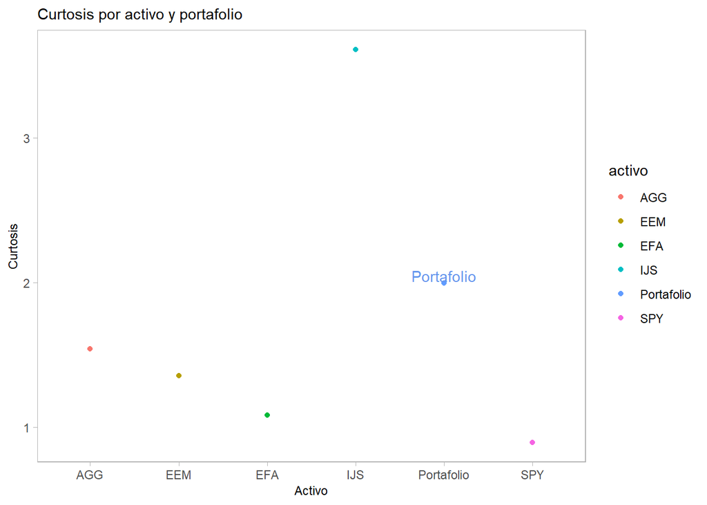

```r
retornos_mes_long %>%
  group_by(activo) %>%
  summarize(kurtosis_accion = kurtosis(retorno)) %>%
  add_row(activo = "Portafolio",
          kurtosis_accion = kurtosis(portfolio_retornos_mes)) %>%
  ggplot(aes(x = activo,
             y = kurtosis_accion,
             colour = activo)) +
  geom_point() +
  annotate("text",
           x = "Portafolio",
           y = kurtosis(portfolio_retornos_mes) + 0.05,
           label = "Portafolio", color = "cornflowerblue") +
  theme_light() +
  labs(title = "Curtosis por activo y portafolio", x = "Activo", y = "Curtosis") +
  theme(plot.title = element_text(size = 11),
        axis.title = element_text(size = 9),
        panel.grid = element_blank())
```

## Curtosis con ventana móvil

```r
ventana <- 24

rolling_kurtosis <- rollapply(data = portfolio_retornos_mes,
                          width = ventana,
                          FUN = kurtosis) %>%
  na.omit()

highchart(type = "stock") %>%
  hc_title(text = "Curtosis movil de 24 meses") %>%
  hc_add_series(rolling_kurtosis,
                color = "cornflowerblue",
                name = "Curtosis") %>%
  hc_add_theme(hc_theme_gridlight()) %>%
  hc_yAxis(title = list(text = "Exceso de Curtosis"),
           opposite = FALSE) %>%
  hc_navigator(height = 20) %>%
  hc_scrollbar(enabled = F) %>%
  hc_exporting(enabled= T)
```

[interactive chart not shown]

# Parte 4 — Valor en riesgo (VaR)

```r
var_activos <- VaR(R = retornos_mes, p = 0.05, invert = T)
var_activos
```

```
##             SPY         EFA         IJS         EEM        AGG
## VaR -0.06002918 -0.06964572 -0.09284017 -0.08477074 -0.0195892
```

```r
var_portafolio <- VaR(R = portfolio_retornos_mes, p = 0.05, invert = T)
var_portafolio
```

```
##        retornos
## VaR -0.06256097
```

## Valor en riesgo por activo

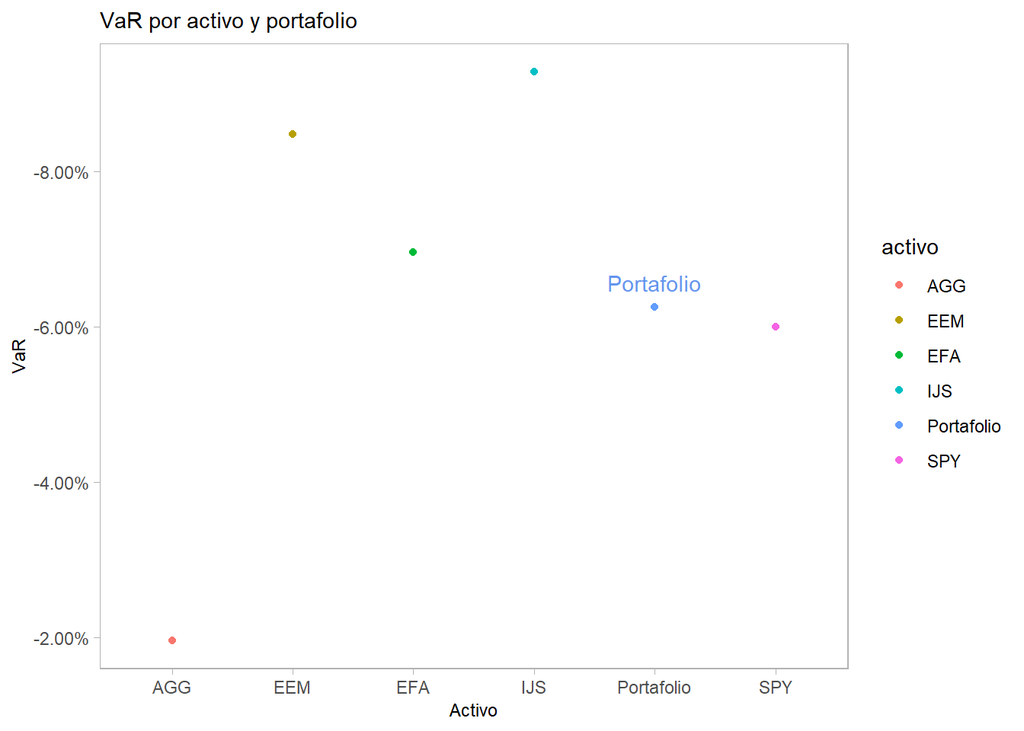

```r
retornos_mes_long %>%
  group_by(activo) %>%
  summarize(var_accion = VaR(R = retorno, invert = T, p = 0.05)) %>%
  add_row(activo = "Portafolio",
          var_accion = VaR(R = portfolio_retornos_mes, p = 0.05, invert = T)) %>%
  ggplot(aes(x = activo,
             y = var_accion,
             colour = activo)) +
  geom_point() +
  annotate("text",
           x = "Portafolio",
           y = VaR(R = portfolio_retornos_mes, p = 0.05, invert = T) * 1.05,
           label = "Portafolio", color = "cornflowerblue") +
  theme_light() +
  labs(title = "VaR por activo y portafolio", x = "Activo", y = "VaR") +
  theme(plot.title = element_text(size = 11),
        axis.title = element_text(size = 9),
        panel.grid = element_blank()) +
    scale_y_continuous(labels = label_percent(accuracy = 0.01),
                       transform = transform_reverse())
```

## Valor en riesgo vs retorno esperado

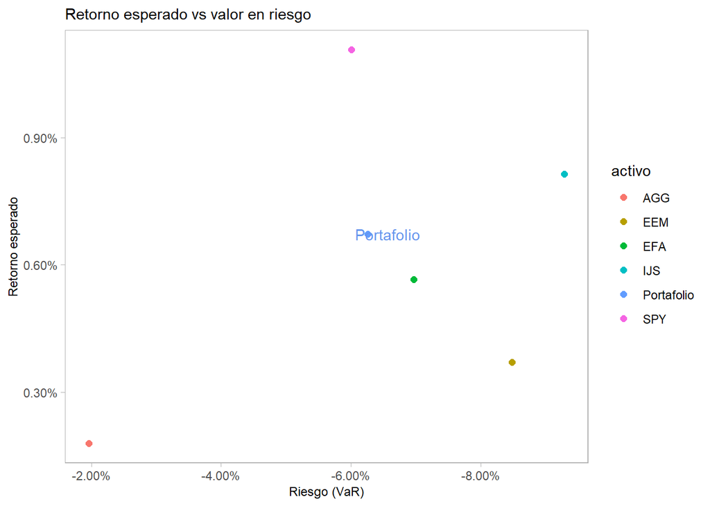

```r
retornos_mes_long %>%
  group_by(activo) %>%
  summarise(retorno_esperado = mean(retorno),
            var = VaR(R = retorno, p = 0.05, invert = T)) %>%
  add_row(activo = "Portafolio",
          var = VaR(R = portfolio_retornos_mes, p = 0.05, invert = T),
          retorno_esperado = mean(portfolio_retornos_mes)) %>%
  ggplot(aes(x = var,
             y = retorno_esperado,
             color = activo)) +
  geom_point(size = 2) +
  annotate("text",
           x = VaR(R = portfolio_retornos_mes, p = 0.05, invert = T) * 1.05,
           y = mean(portfolio_retornos_mes),
           label = "Portafolio",
           color = "cornflowerblue") +
  theme_light() +
  labs(title = "Retorno esperado vs valor en riesgo",
       x = "Riesgo (VaR)",
       y = "Retorno esperado") +
  theme(plot.title = element_text(size = 11),
        axis.title = element_text(size = 9),
        panel.grid = element_blank()) +
  scale_y_continuous(labels = label_percent(accuracy = 0.01)) +
  scale_x_continuous(labels = label_percent(accuracy = 0.01),
                     transform = transform_reverse())
```

## Valor en riesgo con ventana móvil

```r
ventana <- 24

rolling_var <- rollapply(data = portfolio_retornos_mes,
                        width = ventana,
                        FUN = function(x) VaR(R = x, p = 0.05, invert = T)) %>%
  na.omit()

highchart(type = "stock") %>%
  hc_title(text = "Valor en riesgo movil de 24 meses") %>%
  hc_add_series(rolling_var*100,
                color = "cornflowerblue",
                name = "VaR") %>%
  hc_add_theme(hc_theme_gridlight()) %>%
  hc_yAxis(title = list(text = "VaR"),
           opposite = FALSE,
           reversed = TRUE,
           labels = list(format = "{value}%")) %>%
  hc_navigator(height = 20) %>%
  hc_scrollbar(enabled = F) %>%
  hc_exporting(enabled= T)
```

[interactive chart not shown]

# Parte 5 — Pérdida esperada (ES)

**Qué hace**: igual que la Parte 4, pero con Expected Shortfall — el promedio de las pérdidas dado que ya se cayó en el peor 5% de los casos.

**Por qué (teoría)**: mismo argumento que en la unidad de VaR/ES, ahora aplicado a datos históricos reales en vez de simulados — el ES siempre es igual o más severo que el VaR al mismo nivel de confianza, y es especialmente más severo cuanto más gorda sea la cola izquierda de la distribución (es decir, cuanto mayor sea el exceso de curtosis visto en la Parte 3).

```r
es_activos <- ES(R = retornos_mes, p = 0.05, invert = T)
es_activos
```

```
##           SPY        EFA        IJS        EEM         AGG
## ES -0.0878947 -0.1011224 -0.1686086 -0.1245281 -0.02910148
```

```r
es_portafolio <- ES(R = portfolio_retornos_mes, p = 0.05, invert = T)
es_portafolio
```

```
##       retornos
## ES -0.09994013
```

## Pérdida esperada por activo

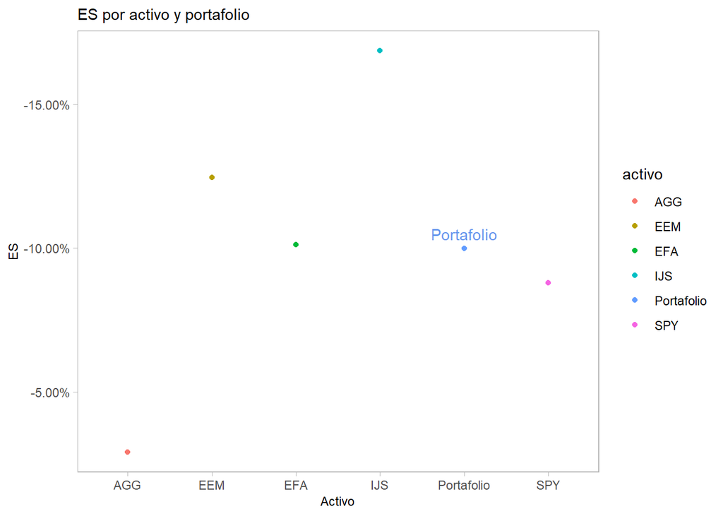

```r
retornos_mes_long %>%
  group_by(activo) %>%
  summarize(es_accion = ES(R = retorno, invert = T, p = 0.05)) %>%
  add_row(activo = "Portafolio",
          es_accion = ES(R = portfolio_retornos_mes, p = 0.05, invert = T)) %>%
  ggplot(aes(x = activo,
             y = es_accion,
             colour = activo)) +
  geom_point() +
  annotate("text",
           x = "Portafolio",
           y = ES(R = portfolio_retornos_mes, p = 0.05, invert = T) * 1.05,
           label = "Portafolio", color = "cornflowerblue") +
  theme_light() +
  labs(title = "ES por activo y portafolio", x = "Activo", y = "ES") +
  theme(plot.title = element_text(size = 11),
        axis.title = element_text(size = 9),
        panel.grid = element_blank()) +
  scale_y_continuous(labels = label_percent(accuracy = 0.01),
                     transform = transform_reverse())
```

## Pérdida esperada vs retorno esperado

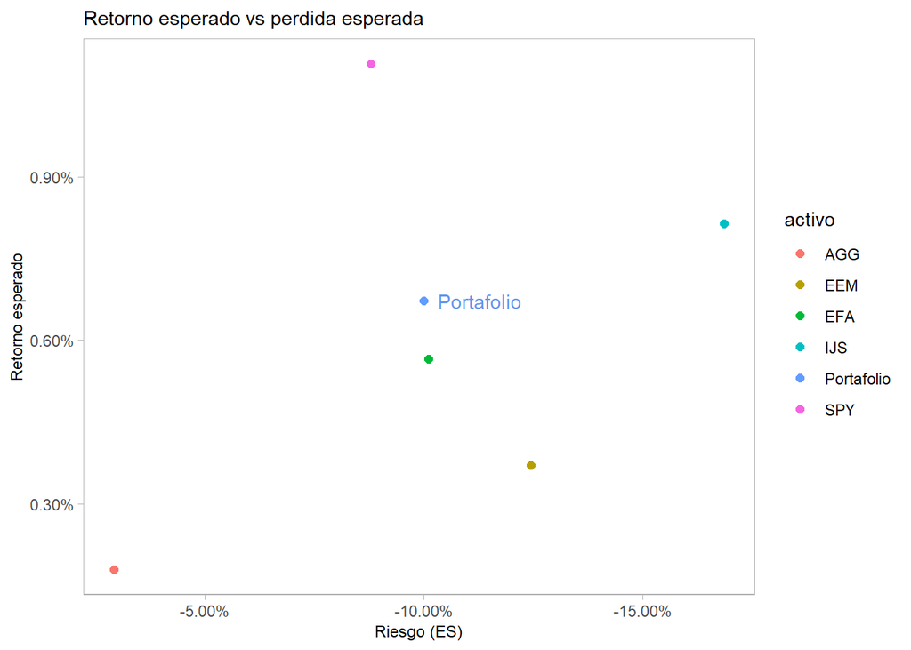

```r
retornos_mes_long %>%
  group_by(activo) %>%
  summarise(retorno_esperado = mean(retorno),
            ES = ES(R = retorno, p = 0.05, invert = T)) %>%
  add_row(activo = "Portafolio",
          ES = ES(R = portfolio_retornos_mes, p = 0.05, invert = T),
          retorno_esperado = mean(portfolio_retornos_mes)) %>%
  ggplot(aes(x = ES,
             y = retorno_esperado,
             color = activo)) +
  geom_point(size = 2) +
  annotate("text",
           x = ES(R = portfolio_retornos_mes, p = 0.05, invert = T) * 1.13,
           y = mean(portfolio_retornos_mes),
           label = "Portafolio",
           color = "cornflowerblue") +
  theme_light() +
  labs(title = "Retorno esperado vs perdida esperada",
       x = "Riesgo (ES)",
       y = "Retorno esperado") +
  theme(plot.title = element_text(size = 11),
        axis.title = element_text(size = 9),
        panel.grid = element_blank()) +
  scale_y_continuous(labels = label_percent(accuracy = 0.01)) +
  scale_x_continuous(labels = label_percent(accuracy = 0.01),
                     transform = transform_reverse())
```

## Pérdida esperada con ventana móvil

```r
ventana <- 24

rolling_es <- rollapply(data = portfolio_retornos_mes,
                        width = ventana,
                        FUN = function(x) ES(R = x, p = 0.05, invert = T)) %>%
  na.omit()

highchart(type = "stock") %>%
  hc_title(text = "Perdida esperada movil de 24 meses") %>%
  hc_add_series(rolling_es*100,
                color = "cornflowerblue",
                name = "ES") %>%
  hc_add_theme(hc_theme_gridlight()) %>%
  hc_yAxis(title = list(text = "ES"),
           opposite = FALSE,
           reversed = TRUE,
           labels = list(format = "{value}%")) %>%
  hc_navigator(height = 20) %>%
  hc_scrollbar(enabled = F) %>%
  hc_exporting(enabled= T)
```

[interactive chart not shown]

**Respuesta:** con las 5 medidas en conjunto, el portafolio diversificado sale con desviación estándar de **3.90%**, por debajo de sus componentes más riesgosos (IJS y EEM), y con VaR(95%) de **-6.26%** y ES(95%) de **-9.99%** — la diferencia entre ambos (ES siempre más severo) es justamente la cola que la desviación estándar por sí sola no alcanza a describir.